# Notebook

```python
import pandas
import matplotlib.pyplot as plt
import matplotlib
import datetime
import dateutil.parser
```

```python
%matplotlib inline
matplotlib.rcParams['figure.figsize'] = (20.0, 10.0)
```

The data files are a save of the terminal. As it's unlikely that they'll be saved this way again I'm going to do some preprocessing by hand on them.

They curently look like this.

```
Last login: Thu Jul  7 17:41:05 on ttys006
Annisas-MacBook-Pro:~ annisariverar$ ssh pi@10.2.250.108
pi@10.2.250.108's password:

The programs included with the Debian GNU/Linux system are free software;
the exact distribution terms for each program are described in the
individual files in /usr/share/doc/*/copyright.

Debian GNU/Linux comes with ABSOLUTELY NO WARRANTY, to the extent
permitted by applicable law.
Last login: Thu Jul  7 07:13:49 2016 from 10.2.250.106
pi@raspberrypi:~ $ cd code2016/
pi@raspberrypi:~/code2016 $ cd courierbeacons/
pi@raspberrypi:~/code2016/courierbeacons $ sudo python testble.py
{"__v":0,"_id":"577e0708191d16ed086cea33","approvedStatus":"Pending","customId":"RPi one metre ","ipAddress":"10.2.250.108","lastSeen":"2016-07-07T07:38:48.166Z","location":"config.agent.location","name":"config.agent.name","operationalStatus":"Failure","range":1,"registered":"2016-07-07T07:38:48.166Z","capabilities":["config.agent.capabilities"]}
ble thread started
{'major': '5', 'uuid': 'd0d3fa86ca7645ec9bd96af400000005', 'tx': '-58', 'time': '2016-07-07T07:52:41.730228', 'rssi': '-71', 'agentId': 'RPi one metre ', 'minor': '5'}
{'major': '9752', 'uuid': 'd0d3fa86ca7645ec9bd96af4022e7550', 'tx': '-65', 'time': '2016-07-07T07:52:42.319354', 'rssi': '-78', 'agentId': 'RPi one metre ', 'minor': '43912'}
{'major': '5', 'uuid': 'd0d3fa86ca7645ec9bd96af400000005', 'tx': '-58', 'time': '2016-07-07T07:52:42.687340', 'rssi': '-78', 'agentId': 'RPi one metre ', 'minor': '5'}
```

I'm going to delete the header and manually turn them into json. I.e. put it all inside [] and add commas at the ends of the lines. Single quotes isn't legit json, so I replaced the ' with ".

There are a few places that have odd data, so I'm just manually getting rid of that too.

```python
data1 = pandas.read_json("1m - 01.json")
# data1 = pandas.read_json("1m - 02.json")
# data1 = pandas.read_json("2m - 01.json")
```

Let's take a look at what the resulting data looks like in a Pandas dataframe

```python
data1.head()
```

|  | agentId | major | minor | rssi | time | tx | uuid |
| --- | --- | --- | --- | --- | --- | --- | --- |
| 0 | RPi one metre | 5 | 5 | -71 | 2016-07-07T07:52:41.730228 | -58 | d0d3fa86ca7645ec9bd96af400000005 |
| 1 | RPi one metre | 9752 | 43912 | -78 | 2016-07-07T07:52:42.319354 | -65 | d0d3fa86ca7645ec9bd96af4022e7550 |
| 2 | RPi one metre | 5 | 5 | -78 | 2016-07-07T07:52:42.687340 | -58 | d0d3fa86ca7645ec9bd96af400000005 |
| 3 | RPi one metre | 9752 | 43912 | -80 | 2016-07-07T07:52:43.351419 | -65 | d0d3fa86ca7645ec9bd96af4022e7550 |
| 4 | RPi one metre | 9752 | 43912 | -88 | 2016-07-07T07:52:44.262536 | -65 | d0d3fa86ca7645ec9bd96af4022e7550 |

How about a histogram of the distribution of the rssi values?

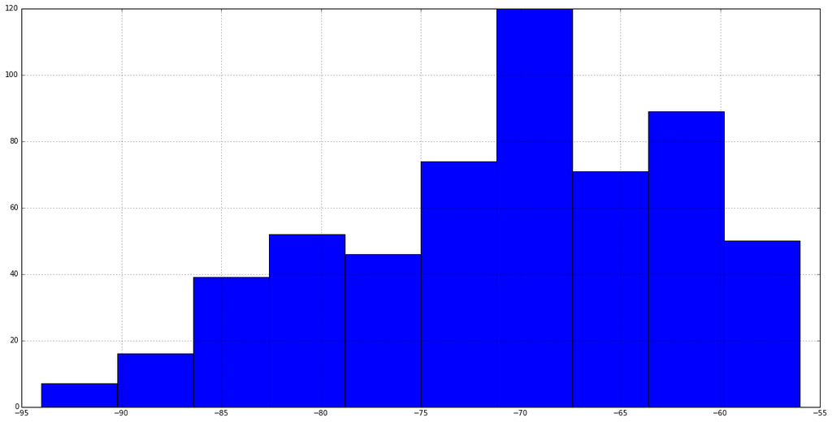

```python
data1.rssi.hist()
```

If we look at the `type` of the time columns we can see that it's a unicode string, not a date time. If the columns were named differently then it'd be fine (See [`convert_dates` here](http://pandas.pydata.org/pandas-docs/stable/generated/pandas.read_json.html)). As it's not we need to convert it.

```python
print data1.time[0]
print type(data1.time[0])
```

```
2016-07-07T07:52:41.730228
<type 'unicode'>
```

```python
def convert_timestring(row):
    return dateutil.parser.parse(row.time)


data1["timestamp"] = data1.apply (lambda row: convert_timestring(row), axis=1)
```

This looks hardcore, but it just goes down the table making a new cell in each row that's formatted as a date not a string.